# Visualising and Testing Data

4 April 2018

## Load data

```r
> choc <- read.csv('choccies.csv', header = T, sep = ',')
> library(dplyr)
```

```
Attaching package: 'dplyr'
```

```
The following objects are masked from 'package:stats':

    filter, lag
```

```
The following objects are masked from 'package:base':

    intersect, setdiff, setequal, union
```

```r
> library(reshape2)
```

## Tidy choccies

```r
> choc_long <- choc %>%
+   melt(id = 1)
```

```r
> head(choc_long)
```

| Group | variable | value |
| --- | --- | --- |
| Cognitive | boost | 0.20 |
| DevSci | boost | 1.00 |
| QSP | boost | 0.60 |
| Cognitive | bounty | 0.70 |
| DevSci | bounty | 0.40 |
| QSP | bounty | 0.28 |

## And rename

- We can rename like I did before, with

```r
> names(choc_long)[c(2,3)] <- c('Choccy', 'Prop')
```

- or we can use dplyr::rename

```r
> choc_long <- choc_long %>%
+   rename(Choccy = variable, Prop = value)
```

## Renaming

- Which gives us:

```r
> head(choc_long)
```

| Group | Choccy | Prop |
| --- | --- | --- |
| Cognitive | boost | 0.20 |
| DevSci | boost | 1.00 |
| QSP | boost | 0.60 |
| Cognitive | bounty | 0.70 |
| DevSci | bounty | 0.40 |
| QSP | bounty | 0.28 |

## Plotting our results

- Just like othe*R* things, there is more than one way to do this
- The two main ways are base R (like our plot() function earlier) and ggplot2
- ggplot2 is basically awesome
- There are other underrated alternatives like lattice and ggplot2::qplot

## Base R

- really easy to use, horrible to get perfect
- Great for quick summaries

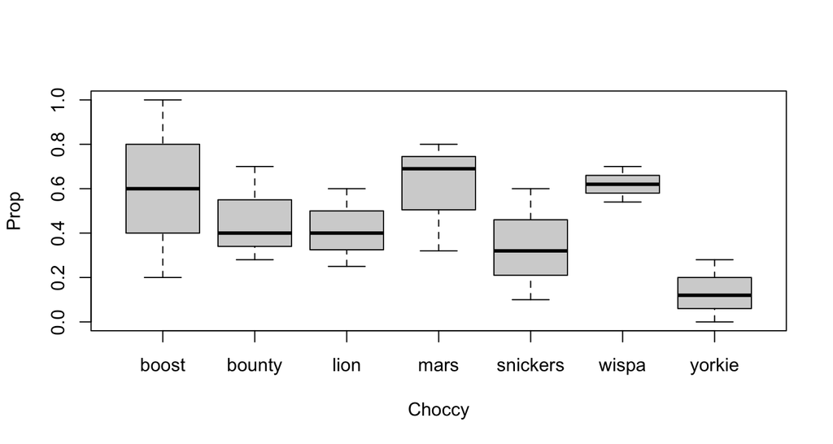

```r
> boxplot(Prop ~ Choccy, data = choc_long)
```

## ggplot2

- ggplot is fully customisable and well-documented (and pretty)
- But we need to learn the syntax
- It’s done by layers, where we add a layer each time
- Start by defining ggplot

## ggplot2

```r
> library(ggplot2)
> cplot <- ggplot(data = choc_long)
```

## ggplot2

- We need to add aesthetics to make sure it maps properly

```r
> cplot <- ggplot(data = choc_long,
+                 aes(x = Choccy, y = Prop))
```

## ggplot2

- Then we add our layers
- We can do this with either stat_summary() or geom_xxx()
- In most cases stat_summary is what you want
- Except boxplots or histograms basically!

## ggplot2

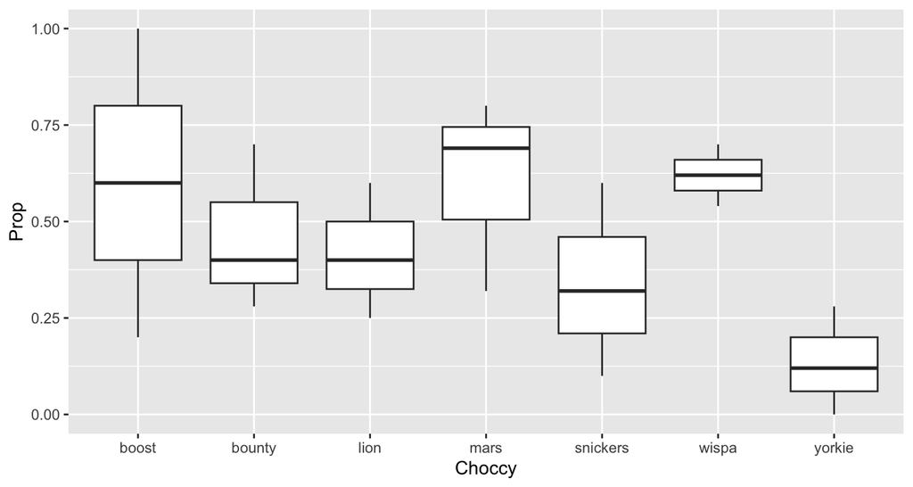

```r
> cplot + geom_boxplot()
```

## How about by group?

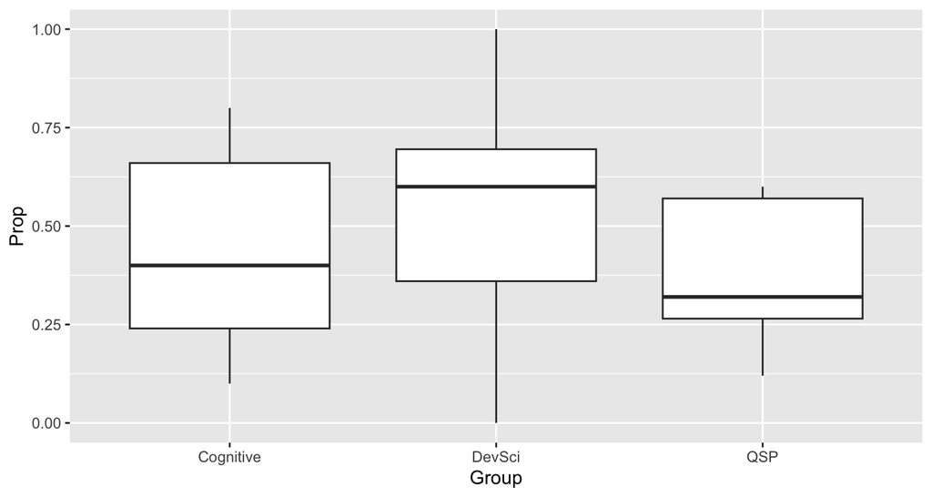

```r
> cplot <- ggplot(data = choc_long,
+                 aes(x = Group, y = Prop)) +
+   geom_boxplot()
> cplot
```

## What if we want more???

- We can overwrite the aesthetics in additional layers if we want to
- This is super useful for plotting things like model fit vs data
- Gives us a lot of flexibility

## Adding layers

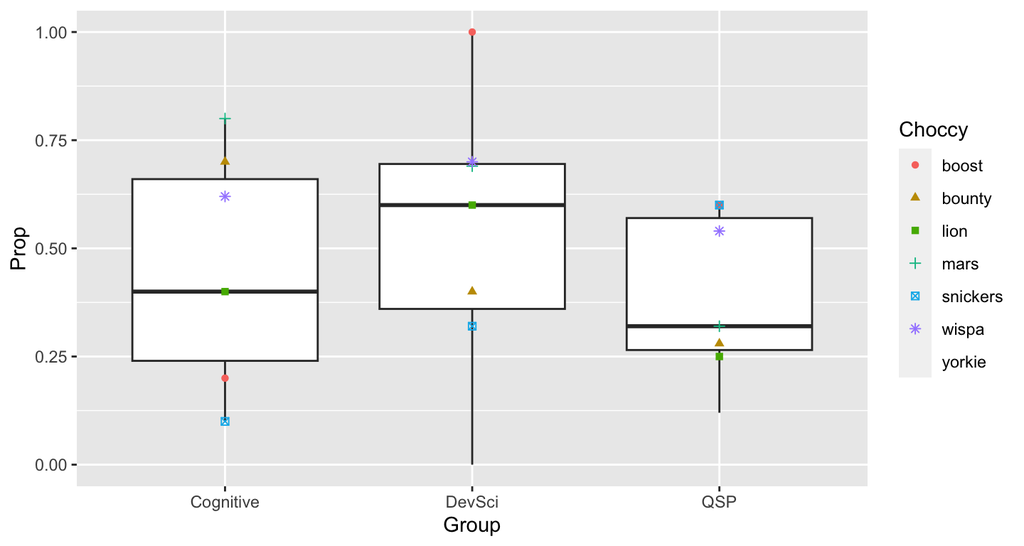

```r
> cplot + stat_summary(aes(colour = Choccy, shape = Choccy),
+                      geom = 'point', fun.y = 'mean')
```

## Adding layers

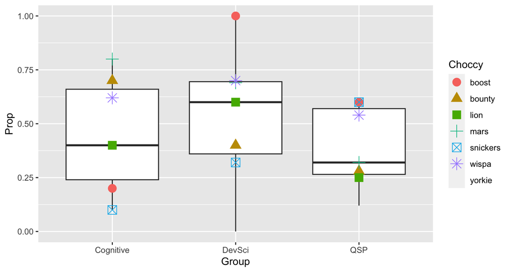

```r
> cplot + stat_summary(aes(colour = Choccy, shape = Choccy),
+                      geom = 'point', fun.y = 'mean',
+                      size = 4)
```

## Adding layers

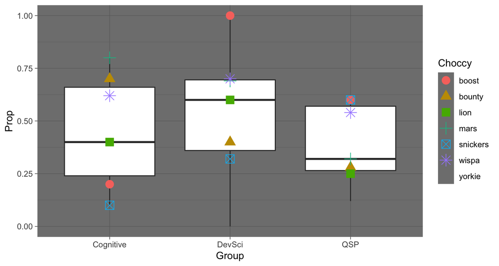

```r
> cplot + stat_summary(aes(colour = Choccy, shape = Choccy),
+                      geom = 'point', fun.y = 'mean',
+                      size = 4) +
+   theme_dark()
```

## Adding layers

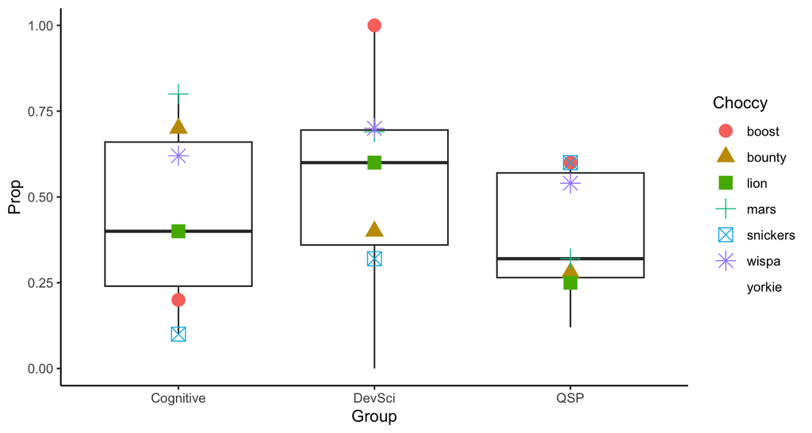

```r
> cplot + stat_summary(aes(colour = Choccy, shape = Choccy),
+                      geom = 'point', fun.y = 'mean',
+                      size = 4) +
+   theme_classic()
```

## Modern plotting styles

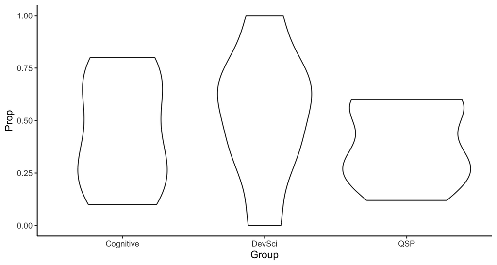

```r
> cplot <- ggplot(data = choc_long,
+                 aes(x = Group, y = Prop)) +
+   geom_violin() + theme_classic()
> cplot
```

## Modern plotting styles

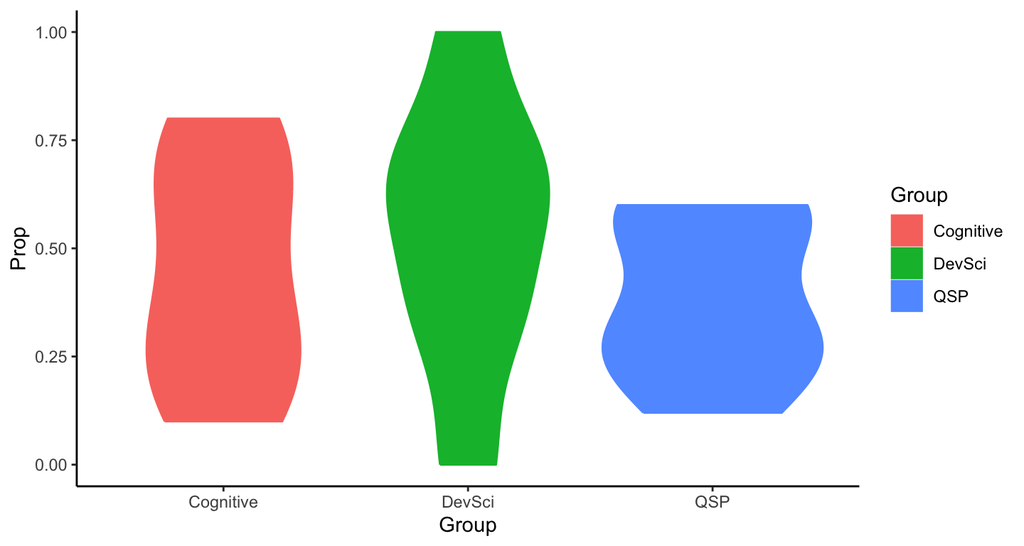

```r
> cplot <- ggplot(data = choc_long,
+                 aes(x = Group, y = Prop, colour = Group, fill = Group)) +
+   geom_violin() + theme_classic()
> cplot
```

## Great data visualisation

```r
> cplot <- ggplot(data = choc_long,
+                 aes(x = Group, y = Prop, colour = Group, fill = Group)) +
+   geom_violin(alpha = 0.2) +
+   stat_summary(geom = 'pointrange', fun.data = 'mean_se') +
+   theme_classic() +
+   ylab('Proportion') +
+   xlab('Research Group')
```

## Great data visualisation

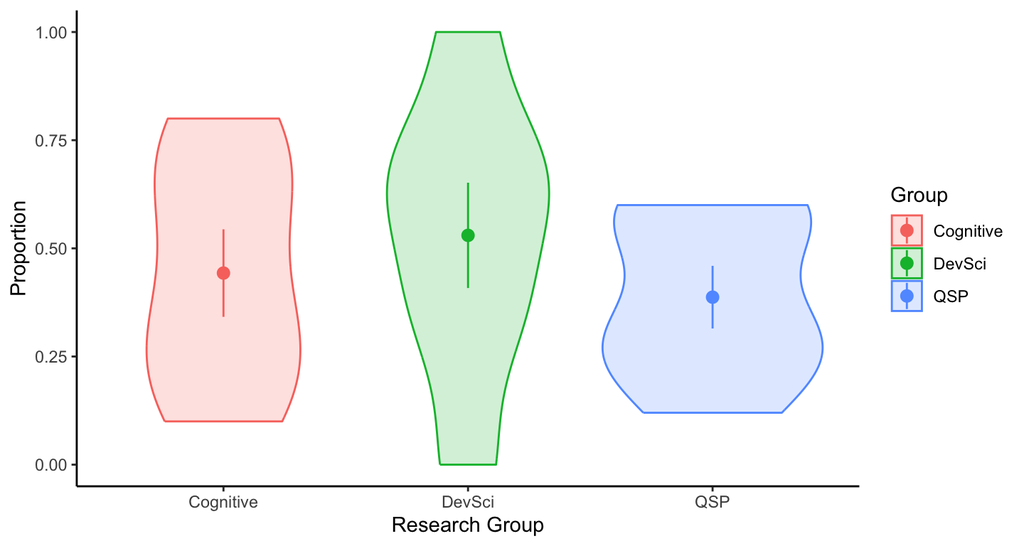

```r
> cplot
```

## Student’s Sleep Data

- In 1905, Cushny and Peebles looked at the effect of two soporific drugs on 10 patients
- This was famously re-analyzed by *Student* in 1908, introducing what we now know as the *t*-test
- Fun fact, *Student* was William Sealy Gosset, who was working for Guinness at the time, and the test was used to measure the quality of the beer
- This is a built-in dataset in R

## Student’s Sleep Data

```r
> sleep <- sleep
```

```r
> head(sleep)
```

| extra | group | ID |
| --- | --- | --- |
| 0.7 | 1 | 1 |
| -1.6 | 1 | 2 |
| -0.2 | 1 | 3 |
| -1.2 | 1 | 4 |
| -0.1 | 1 | 5 |
| 3.4 | 1 | 6 |

## Student’s sleep data

- *extra* is the increase in hours of sleep
- *group* is the drug given (poorly named)
- *ID* is the patient ID
- How would we describe this???

## Check our data

- As mentioned last week, you should always check the type of data
- You can do this by hovering over each column in View(sleep)
- What are we looking at?

## T-test in R

- Each function has a default behavior
- t.test(x, y = NULL, alternative = c(“two.sided”, “less”, “greater”), mu = 0, paired = FALSE, var.equal = FALSE, conf.level = 0.95, …)
- This example appears in the official R examples, and they forget to pair the data!

## T-test in R

- We want to use the function interface almost all of the time, unless it is comparing to mu
- That is: y ~ x - remember we used that in dcast()

```r
> t.test(extra ~ group, paired = T, data = sleep)
```

```
    Paired t-test

data:  extra by group
t = -4.0621, df = 9, p-value = 0.002833
alternative hypothesis: true mean difference is not equal to 0
95 percent confidence interval:
 -2.4598858 -0.7001142
sample estimates:
mean difference
          -1.58
```

## Plot our results

- What kind of data visualisation is appropriate here?

## Plot our results

- What kind of data visualisation is appropriate here?
- I’m going to say a boxplot, partly because I don’t like barplots
- You can always play with other options

## Plot our results

```r
> splot <- ggplot(data = sleep,
+                 aes(x = group, y = extra)) +
+   geom_boxplot() +
+   theme_classic()
```

## Plot our results

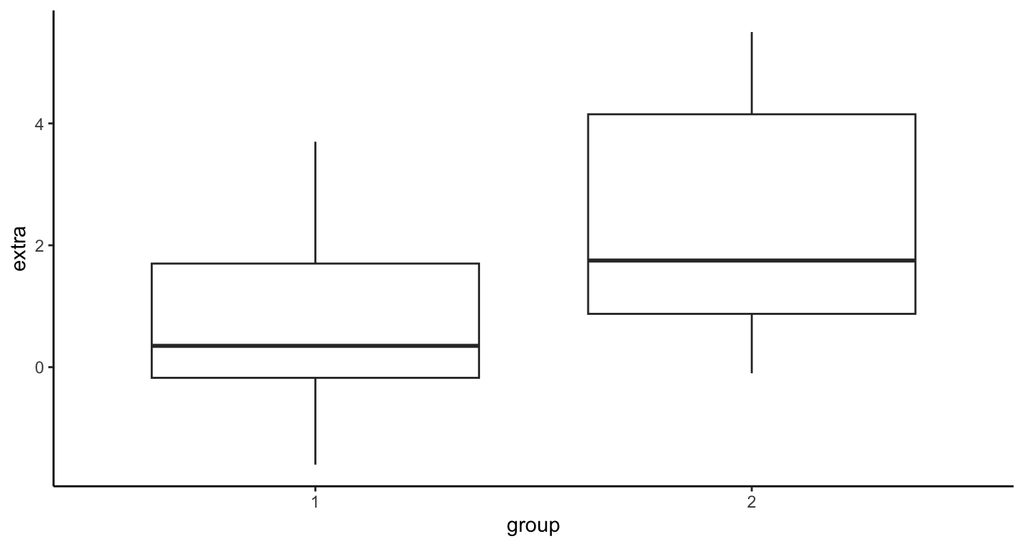

```r
> splot
```

## Add significance marks?

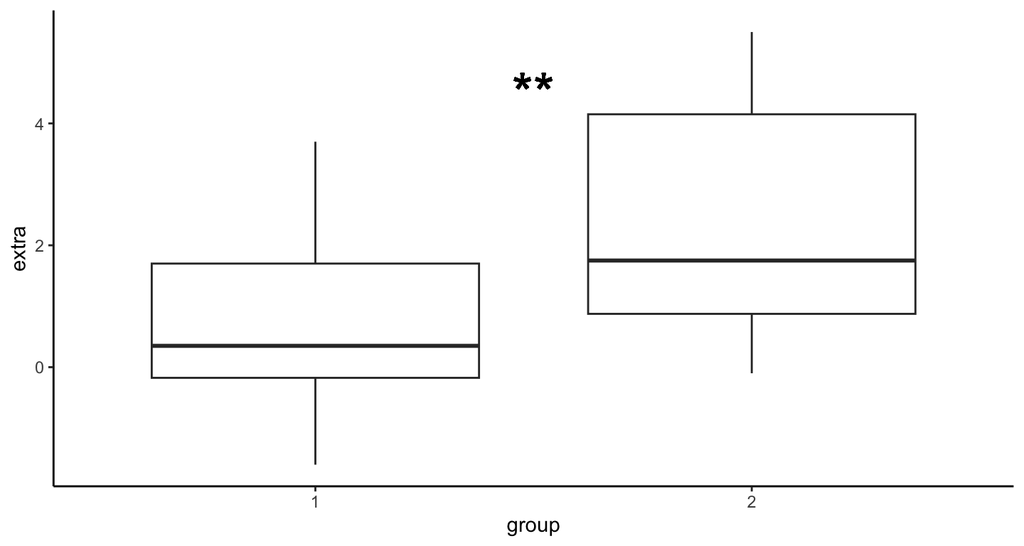

```r
> splot + geom_text(x = 1.5, y = 4.5, label = '**', size = 10)
```

## Plant growth data

- Results of an experiment comparing weight of plants under 3 conditions

```r
> PlantGrowth <- PlantGrowth
```

```r
> head(PlantGrowth)
```

| weight | group |
| --- | --- |
| 4.17 | ctrl |
| 5.58 | ctrl |
| 5.18 | ctrl |
| 6.11 | ctrl |
| 4.50 | ctrl |
| 4.61 | ctrl |

## Doing a linear model

- There are pure anova ways of doing this in other packages
- For us, it is easiest to run it just like a linear model
- We can use the same syntax as in a *t*-test

```r
> pgmod <- lm(weight ~ group, data = PlantGrowth)
```

## Linear model

```r
> summary(pgmod)
```

```
Call:
lm(formula = weight ~ group, data = PlantGrowth)

Residuals:
    Min      1Q  Median      3Q     Max
-1.0710 -0.4180 -0.0060  0.2627  1.3690

Coefficients:
            Estimate Std. Error t value Pr(>|t|)
(Intercept)   5.0320     0.1971  25.527   <2e-16 ***
grouptrt1    -0.3710     0.2788  -1.331   0.1944
grouptrt2     0.4940     0.2788   1.772   0.0877 .
---
Signif. codes:  0 '***' 0.001 '**' 0.01 '*' 0.05 '.' 0.1 ' ' 1

Residual standard error: 0.6234 on 27 degrees of freedom
Multiple R-squared:  0.2641,    Adjusted R-squared:  0.2096
F-statistic: 4.846 on 2 and 27 DF,  p-value: 0.01591
```

## Anova table

- Rather than contrasting, we may wish to see the anova table

```r
> anova(pgmod)
```

```
Analysis of Variance Table

Response: weight
          Df  Sum Sq Mean Sq F value  Pr(>F)
group      2  3.7663  1.8832  4.8461 0.01591 *
Residuals 27 10.4921  0.3886
---
Signif. codes:  0 '***' 0.001 '**' 0.01 '*' 0.05 '.' 0.1 ' ' 1
```

## Plotting

- Can you plot these data?

## Plotting

```r
> pgplot <- ggplot(PlantGrowth,
+                  aes(x = group, y = weight, fill = group)) +
+   geom_boxplot(alpha = 0.4) +
+   theme_classic()
```

## Plotting

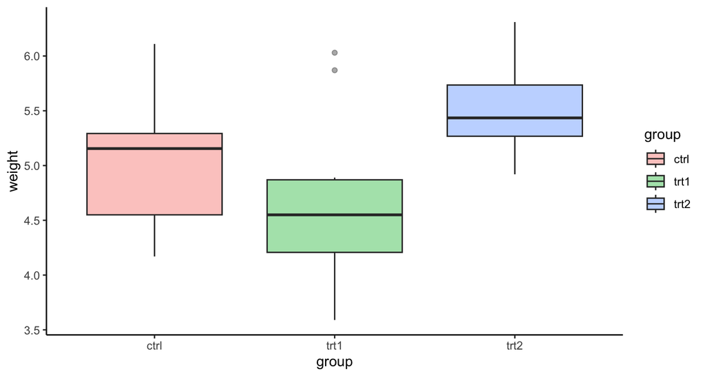

```r
> pgplot
```